# Nonlinear supervised learning

Press the button 'Toggle code' below to toggle code on and off for entire this presentation.

```python
from IPython.display import display
from IPython.display import HTML
import IPython.core.display as di # Example: di.display_html('<h3>%s:</h3>' % str, raw=True)

# This line will hide code by default when the notebook is eåxported as HTML
di.display_html('<script>jQuery(function() {if (jQuery("body.notebook_app").length == 0) { jQuery(".input_area").toggle(); jQuery(".prompt").toggle();}});</script>', raw=True)

# This line will add a button to toggle visibility of code blocks, for use with the HTML export version
di.display_html('''<button onclick="jQuery('.input_area').toggle(); jQuery('.prompt').toggle();">Toggle code</button>''', raw=True)
```

# 1.1 From linear to non-linear modeling

- Thus far we have covered the basics of linear modeling for regression and classification.
- With regression we started with a desire that a dataset could be represented linearly via the model $w_0 + \mathbf{x}_p^T\mathbf{w}_{\,}^{\,} \approx y_p$
- This desire led to the Least Squares cost function for linear regression, which minimized provokes our desire to hold as well as possible.
- So, in other words, ideally we want all our data to lie on some hyperplane $w_0^{\,} + \mathbf{x}_{\,}^T\mathbf{w}_{\,}^{\,} = y_{\,}^{\,}$ in the input/output space
- So our ideal dataset is a bunch of points - with no noise - from a hyperplane

[figure not shown]

- With classification we started with a desire that a dataset could be represented linearly the step function with linear boundary
- A hyperplane in the input space $w_0 + \mathbf{x}_{\,}^T\mathbf{w}_{\,}^{\,} = 0$ where

\begin{equation} \begin{cases} w_0+\mathbf{x}_{p}^{T}\mathbf{w}^{\,} >0 & \,\,\,\,\text{if} \,\,\, y_{p}=+1 \\ w_0+\mathbf{x}_{p}^{T}\mathbf{w}^{\,} < 0 & \,\,\,\,\text{if} \,\,\, y_{p}=-1 \end{cases} \end{equation}

- In other ideally we want data to lie perfectly on a step function $\text{sign}\left(w_0 + \mathbf{x}_{\,}^T\mathbf{w}_{\,}^{\,} \right) = y$

[figure not shown]

### The generalization of this notion for regression

- **for regression:** our data lies perfectly on a nonlinear hyperplane surface
- instead of hyperplane $w_0^{\,} + \mathbf{x}_{\,}^T\mathbf{w}_{\,}^{\,} = y_{\,}^{\,}$ we have some general nonlinear function $f\left(\mathbf{x},\mathbf{w}\right) = y$
- as with linear regression we do not expect perfection!

[figure not shown]

### The generalization of this notion for classification

- **for classification:** our data lies perfectly on step function with linear nonlinear boundary
- instead of separating hyperplane $w_0^{\,} + \mathbf{x}_{\,}^T\mathbf{w}_{\,}^{\,} = 0$ we have some general nonlinear seperator $f\left(\mathbf{x},\mathbf{w}\right) = 0$
- as with linear classification we do not expect perfection!

[figure not shown]

## 1.2 'Simple' examples of nonlinear regression and classification

- For some low-dimensional datasets we could visualize and reason out a proper nonlinear function / separator *by eye*
- In some classical cases from e.g., physics and economics one can reason out the form of a regressor via *philisophical arguments*
- (This is what differential equations and *dynamical systems* are all about)
- In general cannot rely on either our eyes or understanding in general to provide nonlinear form
- Most datasets too high dimensional to visualize, and mechanics lie beyond our comprehension
- So in general we need something more robust - this is where machine learning comes in!
- Tools like neural networks help automate the search for proper nonlinear regressors / boundaries (as do trees and kernels)
- First lets examine some 'easy' cases where we can make a good guess ourselves
- Some important principles, formulations, jargon, etc., from these simple cases carry over to neural networks, trees, kernels, etc.,

## 'Simple' nonlinear regression examples

#### Example 1. A sinusoidal dataset

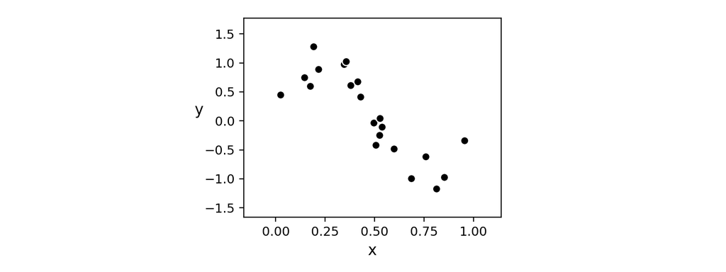

```python
# create instance of linear regression demo, used below and in the next examples
demo1 = nonlib.nonlinear_regression_visualizer.Visualizer(csvname = datapath + 'noisy_sin_sample.csv')
demo1.plot_data(xlabel = 'x',ylabel = 'y')
```

- Looks sinusoidal, i.e., like

\begin{equation} w_0 + w_1\text{sin}\left(w_2 + w_3x_p\right) \approx y_p \end{equation}

could fit the data well if parameters are tuned

- This would give us a nonlinear regressor or predictor of the form

\begin{equation} \text{predict}(x) = w_0 + w_1\text{sin}\left(w_2 + w_3x\right) \end{equation}

- How do we fit? As in the linear case we **want** the above to hold on our data lets square their differences, and minimize a Least Squares cost
- Summing over all $P$ datapoints gives the Least Squares cost function

\begin{equation} g\left(w_0, w_1, w_3, w_4\right) = \sum_{p=1}^P \left(w_0 + w_1\text{sin}\left(w_2 + w_3x_p\right) - y_p\right)^2 = \sum_{p = 1}^P \left(\text{predict}\left(x_p\right) - y_p\right)^2 \end{equation}

- Minimize this by (normalized) gradient descent
- In Python implementation we break the cost into modular pieces
  - the sine nonlinearity --> the prediction --> the cost function

```python
# nonlinearity
def f(x_val,w):
    # create feature
    f_val = np.sin(w[2] + w[3]*x_val)
    return f_val

# prediction
def predict(x_val,w):
    # linear combo
    val = w[0] + w[1]*f(x_val,w)
    return val

# least squares
def least_squares(w):
    cost = 0
    for p in range(0,len(y)):
        x_p = x[p]
        y_p = y[p]
        cost +=(predict(x_p,w) - y_p)**2
    return cost
```

Now we can minimize the cost using gradient descent

We can then plot the resulting fit to the data

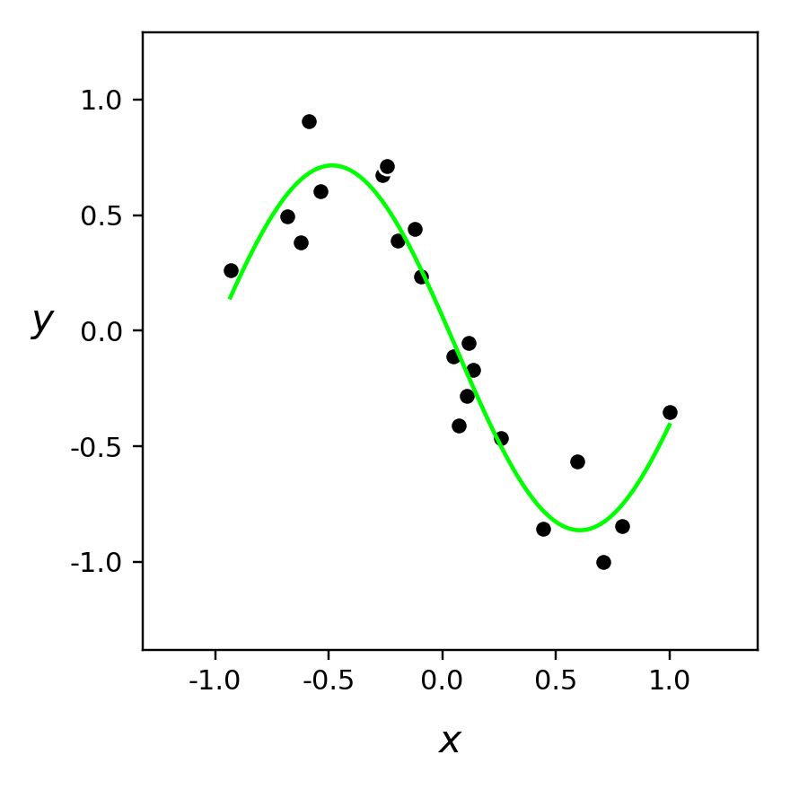

```python
# static transform image
demo1.static_img(w_best,least_squares,predict)
```

- Some common jargon to familiarize yourself with: we have already seen (**now all weights are tuned**)

\begin{equation} \text{predict}(x) = w_0 + w_1\text{sin}\left(w_2 + w_3x\right) \end{equation}

- In particular the nonlinear transformation of $x$ is called a *feature transformation* (we wrote this explicitly in code)

\begin{equation} \text{feature transformation}: f(x) = \text{sin}\left(w_2 + w_3x\right) \end{equation}

- We can write the predictor as

\begin{equation} \text{predict}(x) = w_0 + w_1\,f(x) \end{equation}

\begin{equation} \text{predict}(x) = w_0 + w_1\,f(x) \end{equation}

- In other words, the predictor is a *linear combination* of the feature transform $f(x)$
- Thus in the *transformed feature space* with input horizontal axis $f(x)$ and vertical axis $y$ *our sinusoidal fit is linear*

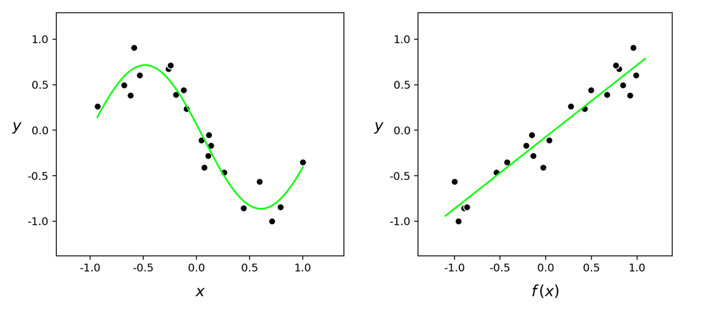

```python
# static transform image
demo1.static_img(w_best,least_squares,predict,f1_x = [f(v,w_best) for v in x])
```

- This is true in general

> A properly designed feature (or set of features) provides a good nonlinear fit in the original feature space and, simultaneously, a good linear fit in the transformed feature space.

#### Example 2. A population growth example

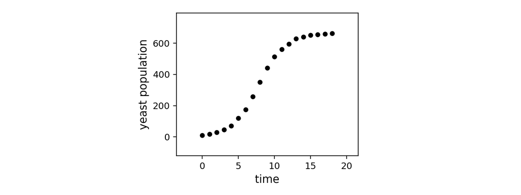

```python
# create instance of linear regression demo, used below and in the next examples
demo2 = nonlib.nonlinear_regression_visualizer.Visualizer(csvname = datapath + 'yeast.csv')

# plot dataset
demo2.plot_data(xlabel = 'time', ylabel = 'yeast population')
```

- What does this look like?
- Certainly looks like a sigmoidal regressor would do the job well here

\begin{equation} \text{predict}(x) = w_0 + w_1\text{tanh}\left(w_2 + w_3x\right) \end{equation}

- Here $f(x) = \text{tanh}\left(w_2 + w_3x\right)$ is our *feature transformation*, and we minimize the Least Squares error

\begin{equation} g\left(w_0, w_1, w_3\right) = \sum_{p = 1}^P \left(\text{predict}\left(x_p\right) - y_p\right)^2 \end{equation}

- Once weights tuned properly this provides linear fit in transformed feature space

```python
# nonlinearity
def f(x,w):
    # shove through nonlinearity
    c = np.tanh( w[2] + w[3]*x)
    return c

# prediction
def predict(x,w):
    # linear combo
    val = w[0] + w[1]*f(x,w)
    return val

# least squares
def least_squares(w):
    cost = 0
    for p in range(0,len(y)):
        x_p = x[p]
        y_p = y[p]
        cost +=(predict(x_p,w) - y_p)**2
    return cost
```

- Center data and minimize via normalized gradient descent

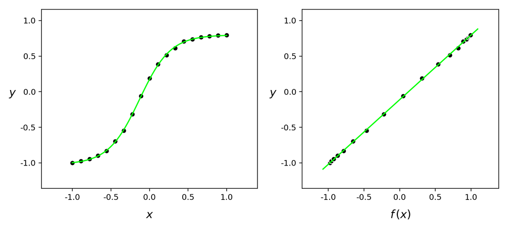

```python
# static transform image
demo2.static_img(w_best,least_squares,predict,f1_x = [f(v,w_best) for v in x])
```

- On the right - data in transformed feature space (note again all weights are now tuned)

#### Example 3. Galileo's ramp experiment

- In 1638 Galileo wants to understand how gravity acts on objects quantify the relationship between
- In particular: how does an object's *distance* from above ground affect the *time* it takes to hit the ground when dropped
- Sets up the following experiment

[figure not shown]

**Figure 1:** *Figurative illustration of Galileo's ramp experiment setup used for exploring the relationship between time and the distance an object falls due to gravity. To perform this experiment he repeatedly rolled a ball down a ramp and timed how long it took to get $\frac{1}{4}$,$\frac{1}{2}$, $\frac{2}{3}$, $\frac{3}{4}$, and all the way down the ramp.*

- Why didn't he just drop the ball and time how long it took to get $\frac{1}{4}$, $\frac{1}{2}$, etc., to the ground?
- Reliable clocks didn't exist yet! (he used a [water clock](https://en.wikipedia.org/wiki/Water_clock).) Galielo's later study of pendulums led to first realiable clock
- He performed this experiment many times and averaged the results, got data like this (from a modern reenactment)

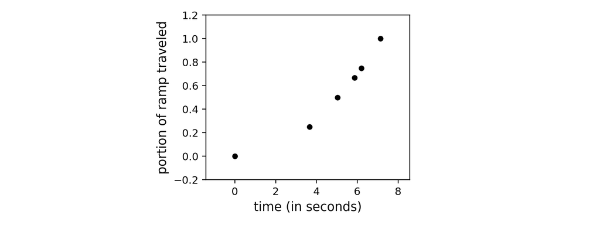

```python
# create instance of linear regression demo, used below and in the next examples
demo3 = nonlib.nonlinear_regression_visualizer.Visualizer(csvname = datapath + 'galileo_ramp_data.csv')

# plot dataset
demo3.plot_data(xlabel = 'time (in seconds)',ylabel = 'portion of ramp traveled')
```

- Clearly a nonlinear relationship - Galileo intuitied a *quadratic* one
- In other words, that for some $w_0$, $w_1$, and $w_2$ that

\begin{equation} \text{predict}(x) = w_0 + w_1x + w_2x^2 \end{equation}

- Here we have 2 feature transformations: the identity $f_1(x) = x$ and $f_2(x) = x^2$ so can write

\begin{equation} \text{predict}(x) = w_0 + w_1\,f_1(x) + w_2\,f_2(x) \end{equation}

- Recover weights by minimizing Least Squares error

\begin{equation} g\left(w_0, w_1, w_3\right) = \sum_{p = 1}^P \left(\text{predict}\left(x_p\right) - y_p\right)^2 \end{equation}

```python
# feature transformation
def f1(x):
    return x

def f2(x):
    return x**2

# prediction
def predict(x,w):
    # linear combo
    a = w[0] + w[1]*f1(x) + w[2]*f2(x)
    return a

# least squares
def least_squares(w):
    cost = 0
    for p in range(0,len(y)):
        x_p = x[p]
        y_p = y[p]
        cost +=(predict(x_p,w) - y_p)**2
    return cost
```

And we optimize using e.g., (unnormalized) gradient descent

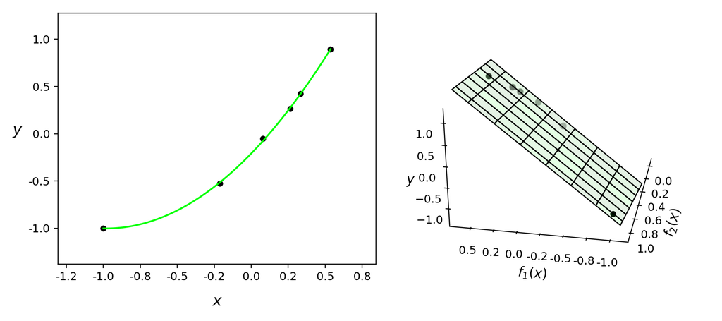

```python
# static transform image
f1_x = [f1(v) for v in x]; f2_x = [f2(v) for v in x]
demo3.static_img(w_best,least_squares,predict,f1_x=f1_x,f2_x=f2_x,view = [35,100])
```

- Here the linear fit is in one dimension higher than where we started!
- True more generally speaking: the more feature transforms we use the higher up we go!

## 'Simple' nonlinear classification examples

#### Example 4. A one dimensional example

- With linear regression we started with a desire that a dataset could be represented linearly via the model $w_0 + {w}_{1}^{\,}{x}_p \approx y_p$
- With logistic regression we started with a desire that a dataset could be represented by shoving line through sigmoid as in $\text{tanh}\left(w_0 + {w}_{1}^{\,}{x}_p\right) \approx y_p$
- Once tuned our decision boundary $w_0 + w_1x = 0$, our decision boundary
- Our predictor is then

\begin{equation} \text{predict}(x) = w_0 +_{\,} w_1x_{\,} \end{equation}

- If $\text{predict}(x) > 0$ then $x$ assigned to $+1$ class, if $\text{predict}(x) < 0$ assigned to $-1$ class

[figure not shown]

- Tune by minimizing e.g., softmax cost

\begin{equation} g\left(w_0,w_1\right) = \sum_{p=1}^{P} \text{log}\left(1 + e^{-y_p\left(w_0 + w_1x_p\right)} \right) = \sum_{p=1}^{P} \text{log}\left(1 + e^{-y_p\, \text{predict}_{}\left(x_p\right)} \right) \end{equation}

- What about this dataset?

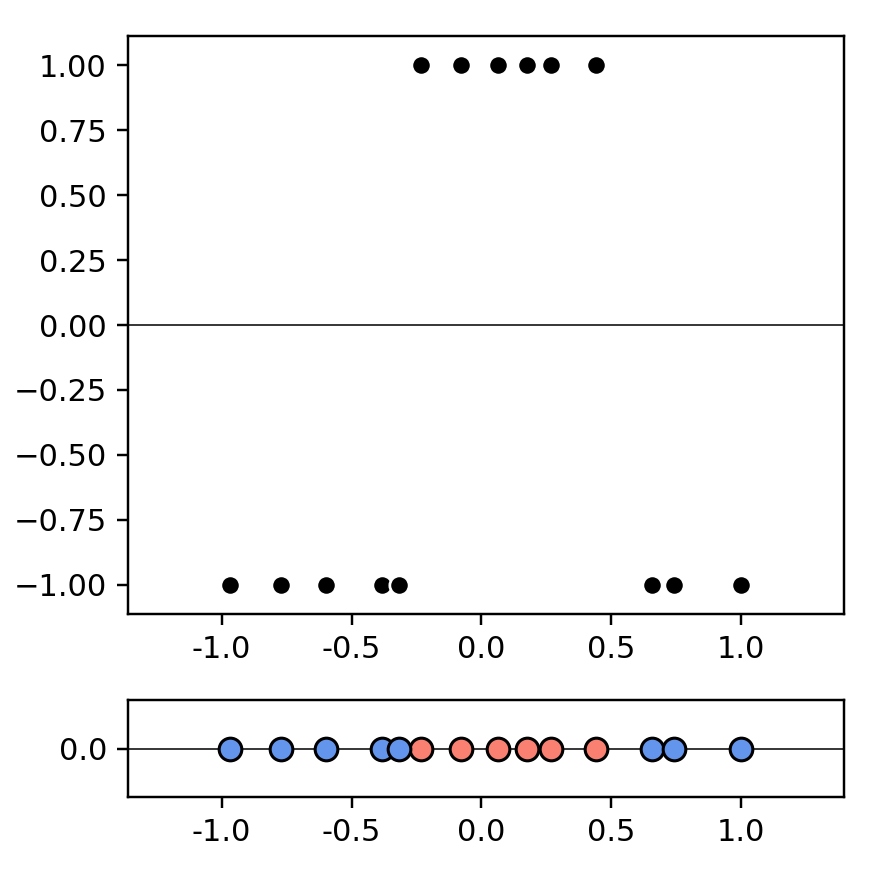

```python
# create instance of linear regression demo, used below and in the next examples
demo4 = nonlib.nonlinear_classification_visualizer.Visualizer(csvname = datapath + 'signed_projectile.csv')

# plot dataset
demo4.plot_data()
```

- How about a quadratic decision boundary: $w_0 + w_1x^{\,} + w_2x^2 = 0$
- If we denote

\begin{equation} \text{predict}(x) = w_0 + w_1x^{\,} + w_2x^2 \end{equation}

then once tuned if $\text{predict}(x) > 0$ $x$ in class $+1$, if $\text{predict}(x)<0$ class $-1$

- Here we have two *feature transformations* (we will write explicitly in code)

\begin{equation} \text{feature transformations}: f_1(x) = x \,\,\,\,\,\, f_2(x) = x^2 \end{equation}

- So we can write our predictor

\begin{equation} \text{predict}(x) = w_0 + w_1\,f_1(x) + w_2\,f_2(x) \end{equation}

[figure not shown]

- Tune weights by minimizing e.g., the softmax cost: $\,g\left(w_0,w_1,w_2\right) = \sum_{p=1}^{P} \text{log}\left(1 + e^{-y_p\, \text{predict}_{}\left(x_p\right)} \right)$

```python
# feature transforms
def f1(x):
    return x

def f2(x):
    return x**2

# prediction
def predict(x,w):
    # linear combo
    val = w[0] + w[1]*f1(x) + w[2]*f2(x)
    return val

# softmax cost
def softmax(w):
    cost = 0
    for p in range(0,len(y)):
        x_p = x[p]
        y_p = y[p]
        cost += np.log(1 + np.exp(-y_p*predict(x_p,w)))
    return cost
```

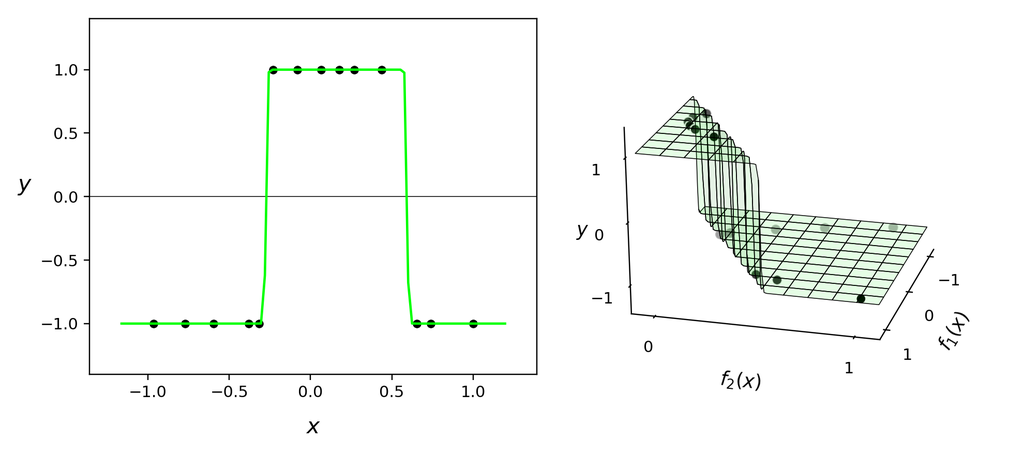

```python
# static transform image
demo4.static_N1_img(w_best,least_squares,predict,f1_x = [f1(s) for s in x], f2_x = [f2(s) for s in x],view = [25,15])
```

> Properly designed features provide good nonlinear separation in the original feature space and, simultaneously, good linear separation in the transformed feature space.

#### Example 5. A two-dimensional example

- How about this dataset?

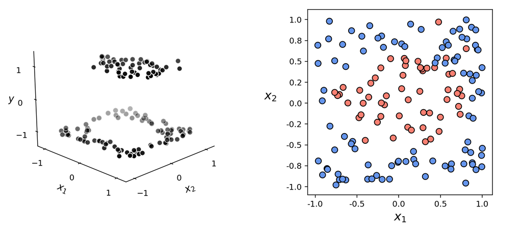

```python
# create instance of linear regression demo, used below and in the next examples
demo5 = nonlib.nonlinear_classification_visualizer.Visualizer(datapath + 'ellipse_2class_data.csv')

# an implementation of the least squares cost function for linear regression for N = 2 input dimension datasets
demo5.plot_data()
```

- How about an elliptical decision boundary?

\begin{equation} \text{predict}(x_1,x_2) = w_0^{\,} + w_1^{\,} x_1^2 + w_2^{\,}x_2^2 \end{equation}

- Here we use two feature transformations $f_1(x_1,x_2)=x_1^2$ and $f_2(x_1,x_2) = x_2^2$

```python
# features
def f1(x):
    return (x[0])**2

def f2(x):
    return (x[1])**2

# prediction
def predict(x,w):
    # linear combo
    a = w[0] + w[1]*f1(x) + w[2]*f2(x)
    return a

# softmax cost
def softmax(w):
    cost = 0
    for p in range(0,len(y)):
        x_p = x[p,:]
        y_p = y[p]
        cost += np.log(1 + np.exp(-y_p*predict(x_p,w)))
    return cost
```

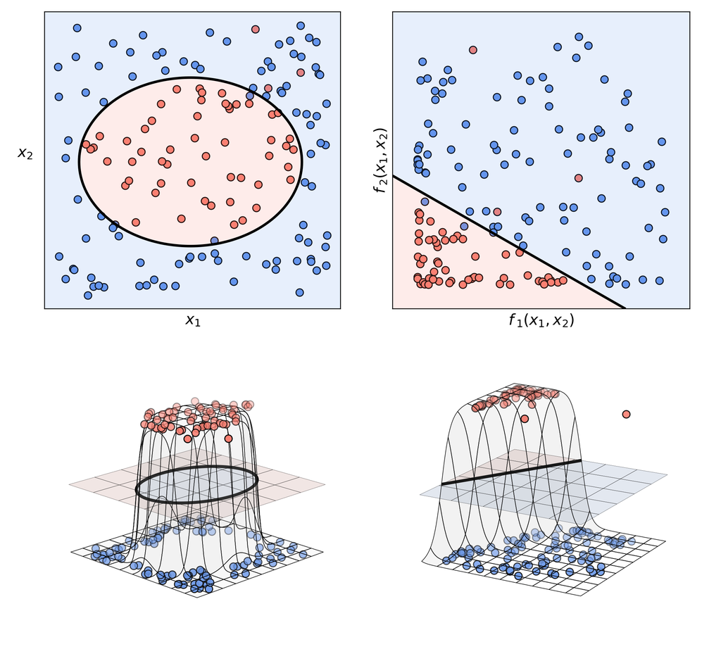

```python
# illustrate results
demo5.static_N2_img(w_best,softmax,predict,f1,f2,view1 = [20,45],view2 = [20,30])
```

## 1.3 Conclusions

- We have seen that when we can identify a candidate nonlinearity we can quickly swap out linearity for nonlinearity in both our regression and classification paradigms
- Each nonlinearity is called a 'transformed feature' or just feature
- **For regression:**

> A properly designed feature (or set of features) provides a good nonlinear fit in the original feature space and, simultaneously, a good linear fit in the transformed feature space.
- **For classification:**

> Properly designed features provide good nonlinear separation in the original feature space and, simultaneously, good linear separation in the transformed feature space.
- But rarely can we identify a complete nonlinearity / all features of a dataset the way we have here ('by eye')
- For example, can you identify the right features for these two datasets?

[figure not shown]

- Pretty hard! And we can visualize these!
- And we have no chance of doing this when we have more than $N = 2$ inputs (we can't visualize!)
- This is where neural networks (as well as kernels and trees) come in!